# Predicting Exercise

This document describes the approach explored / model for the exercise prediction. The data was received using devices that measure different type of activities. Based on those measurements the model tries to define activity performed.

## Data upload and cleaning

Firstly, the raw measurements data provided was uploaded into R.

```r
training <- read.csv("pml-training.csv")
testing <- read.csv("pml-testing.csv")
```

After this some variable summary analysis was performed. It is not shown in the document as a summary on 160 variables can be quite lengthy. It was identified that many variables have too many NAs. Particularly, out of the data set with 160 variables and 19622 rows 67 variables have NAs.

```r
dim(training)
```

```
## [1] 19622   160
```

```r
navar <- sapply(training, function(x) sum(is.na(x)))
length(navar[navar>0])
```

```
## [1] 67
```

```r
quantile(navar[navar>0])
```

```
##    0%   25%   50%   75%  100%
## 19216 19216 19216 19216 19216
```

Those variables have constant quantity of NAs absent. Consequently, they are dropped due to data quality issues.

As a second step - only integer and numeric variables are taken. Those variables are easiest to use. Depending on training results additional variables can be added.

```r
classvar <- sapply(training, function(x) class(x))
filtnames <- names(training[navar == 0 & classvar %in% c("integer", "numeric")])
filtnames <- filtnames[5:length(filtnames)]

# apply variable filter to the imported data
trainingfilt <- training[, c(filtnames, "classe")]
testingfilt <- testing[, c(filtnames)]
```

## Training / validaiton sets and initial data exploration

The training data is split into training and validation set.

The assignment requires prediction the exercise performed by based on test set supplied (20 cases). It worth to check the data if easy wins can be achieved.

Let’s take a look at the predicted variable distribution

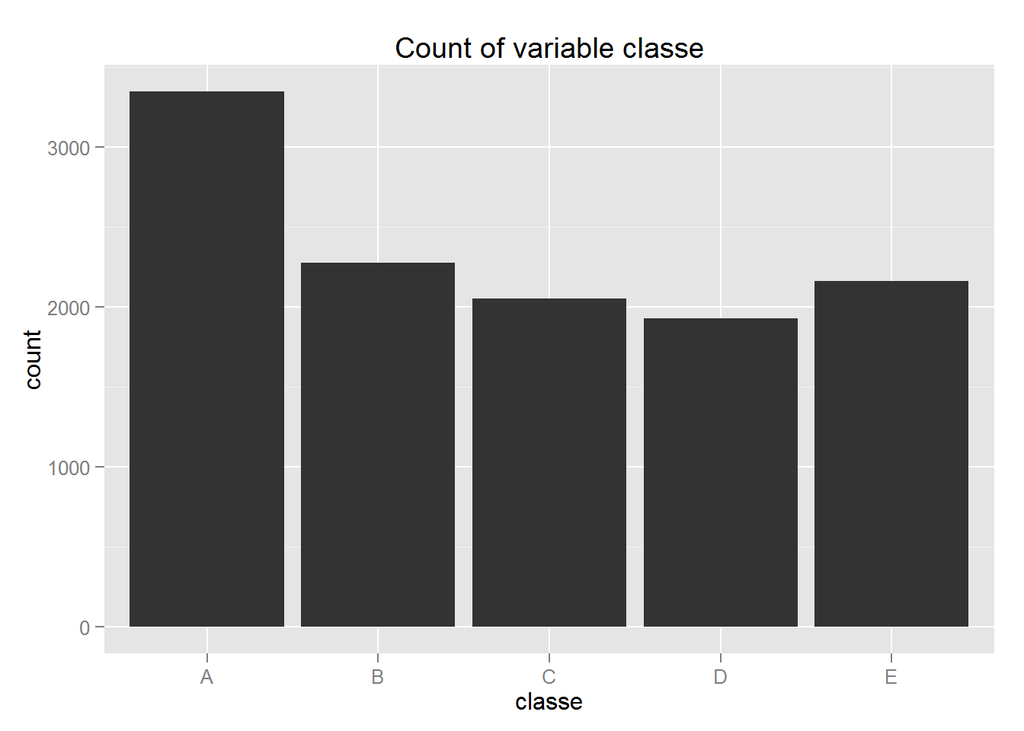

```r
require(ggplot2)
qplot(classe, data = traincl, geom="bar") + labs(title = "Count of variable classe")
```

The training set shows different classes available. Consequently, there is no incentive from the algorithm to simply assign all predictors to one variable (e. g. if 99 out of 100 cases had classe = A).

## Model

Considering the size of the data it was quite difficult to process it without decreasing dimension. So it was decided to pre process it with PCA.

```r
tc <- trainControl(preProcOptions = list(thresh = 0.8))
modfitPCA <- train(classe ~ ., data = traincl, method = "gbm", preProcess = "pca", verbose = FALSE, trControl = tc)
```

The following graph presents relative feature importance:

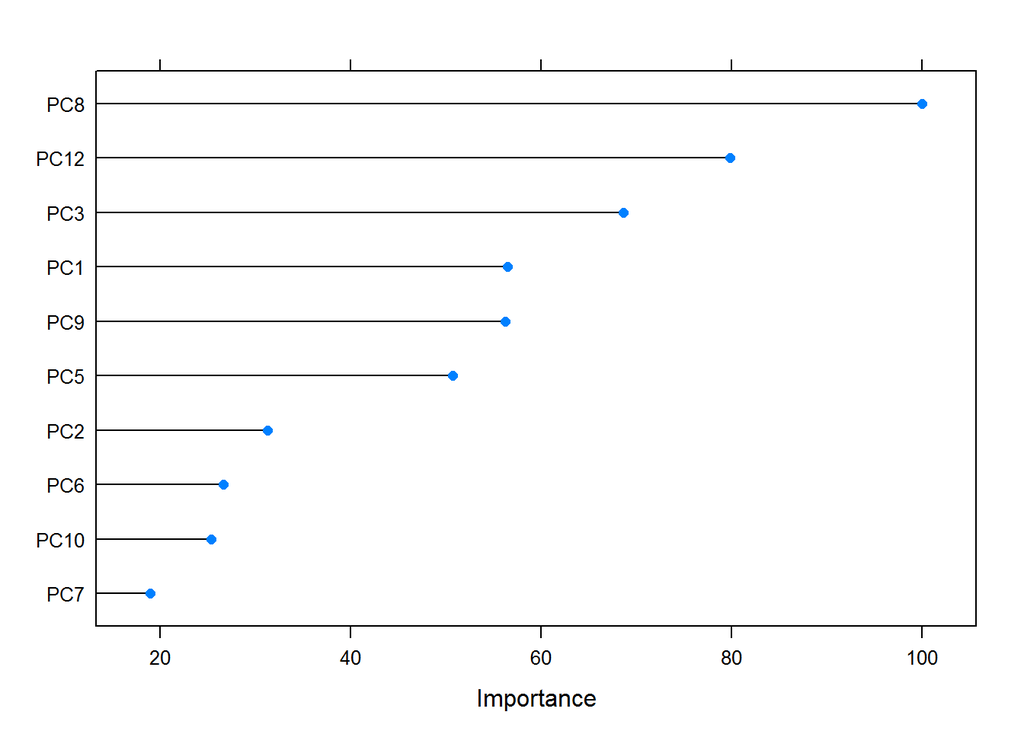

```r
plot(gbmImp, top = 10)
```

## Results

In-sample accuracy is around 80%.

```r
confusionMatrix(traincl$classe, predict(modfitPCA, newdata = traincl[, -53]))
```

```
## Confusion Matrix and Statistics
##
##           Reference
## Prediction    A    B    C    D    E
##          A 2859  108  162  180   39
##          B  199 1688  233  100   59
##          C  193  110 1657   48   46
##          D   97   77  197 1519   40
##          E   99  141  163   88 1674
##
## Overall Statistics
##
##                Accuracy : 0.798
##                  95% CI : (0.791, 0.805)
##     No Information Rate : 0.293
##     P-Value [Acc > NIR] : <2e-16
##
##                   Kappa : 0.744
##  Mcnemar's Test P-Value : <2e-16
##
## Statistics by Class:
##
##                      Class: A Class: B Class: C Class: D Class: E
## Sensitivity             0.829    0.795    0.687    0.785    0.901
## Specificity             0.941    0.939    0.958    0.958    0.950
## Pos Pred Value          0.854    0.741    0.807    0.787    0.773
## Neg Pred Value          0.930    0.954    0.922    0.958    0.981
## Prevalence              0.293    0.180    0.205    0.164    0.158
## Detection Rate          0.243    0.143    0.141    0.129    0.142
## Detection Prevalence    0.284    0.194    0.174    0.164    0.184
## Balanced Accuracy       0.885    0.867    0.822    0.872    0.926
```

Out of sample accuracy is around 75%

```r
confusionMatrix(testcl$classe, predict(modfitPCA, newdata = testcl[, -53]))
```

```
## Confusion Matrix and Statistics
##
##           Reference
## Prediction    A    B    C    D    E
##          A 1841   78  130  139   44
##          B  157 1033  168   85   75
##          C  166   89 1036   28   49
##          D   69   66  129  992   30
##          E   82  112  135   77 1036
##
## Overall Statistics
##
##                Accuracy : 0.757
##                  95% CI : (0.747, 0.766)
##     No Information Rate : 0.295
##     P-Value [Acc > NIR] : <2e-16
##
##                   Kappa : 0.692
##  Mcnemar's Test P-Value : <2e-16
##
## Statistics by Class:
##
##                      Class: A Class: B Class: C Class: D Class: E
## Sensitivity             0.795    0.750    0.648    0.751    0.840
## Specificity             0.929    0.925    0.947    0.955    0.939
## Pos Pred Value          0.825    0.681    0.757    0.771    0.718
## Neg Pred Value          0.916    0.945    0.913    0.950    0.969
## Prevalence              0.295    0.176    0.204    0.168    0.157
## Detection Rate          0.235    0.132    0.132    0.126    0.132
## Detection Prevalence    0.284    0.193    0.174    0.164    0.184
## Balanced Accuracy       0.862    0.837    0.798    0.853    0.889
```